# Predict Bike Sharing Demand with AutoGluon Template

## Project: Predict Bike Sharing Demand with AutoGluon

This notebook is a template with each step that you need to complete for the project.

Please fill in your code where there are explicit `?` markers in the notebook. You are welcome to add more cells and code as you see fit.

Once you have completed all the code implementations, please export your notebook as a HTML file so the reviews can view your code. Make sure you have all outputs correctly outputted.

`File-> Export Notebook As... -> Export Notebook as HTML`

There is a writeup to complete as well after all code implememtation is done. Please answer all questions and attach the necessary tables and charts. You can complete the writeup in either markdown or PDF.

Completing the code template and writeup template will cover all of the rubric points for this project.

The rubric contains "Stand Out Suggestions" for enhancing the project beyond the minimum requirements. The stand out suggestions are optional. If you decide to pursue the "stand out suggestions", you can include the code in this notebook and also discuss the results in the writeup file.

## Step 1: Create an account with Kaggle

### Create Kaggle Account and download API key

Below is example of steps to get the API username and key. Each student will have their own username and key.

1. Open account settings.

2. Scroll down to API and click Create New API Token.

3. Open up `kaggle.json` and use the username and key.


## Step 2: Download the Kaggle dataset using the kaggle python library

### Open up Sagemaker Studio and use starter template

1. Notebook should be using a `ml.t3.medium` instance (2 vCPU + 4 GiB)
2. Notebook should be using kernal: `Python 3 (MXNet 1.8 Python 3.7 CPU Optimized)`

### Install packages

```python
# !pip install -U pip
# !pip install -U setuptools wheel
# !pip install -U "mxnet<2.0.0" bokeh==2.0.1
# !pip install autogluon --no-cache-dir
# Without --no-cache-dir, smaller aws instances may have trouble installing
```

[output not shown]

### Setup Kaggle API Key

```python
# create the .kaggle directory and an empty kaggle.json file
# !mkdir /Users/michaelfronda/Desktop/submit/.kaggle/kaggle.json
# !touch /Users/michaelfronda/Desktop/submit/.kaggle/kaggle.json
!chmod 600 /Users/michaelfronda/Desktop/submit/.kaggle/kaggle.json
```

```python
# Fill in your user name and key from creating the kaggle account and API token file
import json
kaggle_username = ""
kaggle_key = ""

# Save API token the kaggle.json file
with open("/Users/michaelfronda/Desktop/Main/submit/test/kaggle.json", "w") as f:
    f.write(json.dumps({"username": kaggle_username, "key": kaggle_key}))
```

### Download and explore dataset

### Go to the bike sharing demand competition and agree to the terms

```python
import os
os.environ['KAGGLE_CONFIG_DIR'] = "/Users/michaelfronda/Desktop/submit/.kaggle/" # SUPER IMPORTANT
```

```python
# # Download the dataset, it will be in a .zip file so you'll need to unzip it as well.
!kaggle competitions download -c bike-sharing-demand
# # If you already downloaded it you can use the -o command to overwrite the file
# !unzip -o bike-sharing-demand.zip
```

```
Downloading bike-sharing-demand.zip to /Users/michaelfronda/Desktop/submit
```

```python
!unzip -o bike-sharing-demand.zip
```

```
Archive:  bike-sharing-demand.zip
  inflating: sampleSubmission.csv
  inflating: test.csv
  inflating: train.csv
```

# Analysis Starts here

```python
import pandas as pd
from autogluon.tabular import TabularPredictor
```

```python
# Create the train dataset in pandas by reading the csv
# Set the parsing of the datetime column so you can use some of the `dt` features in pandas later
train = pd.read_csv('train.csv', parse_dates=['datetime'])
```

#### Simple output of the train dataset to view some of the min/max/varition of the dataset features.

```python
print('\n------------ Head ------------')
display(train.head())

print('\n------------ Sample 10 ------------')
display(train.sample(10))

print('\n------------ Tail ------------')
display(train.tail())
print()
```

```
------------ Head ------------
```

|  | datetime | season | holiday | workingday | weather | temp | atemp | humidity | windspeed | casual | registered | count |
| --- | --- | --- | --- | --- | --- | --- | --- | --- | --- | --- | --- | --- |
| 0 | 2011-01-01 00:00:00 | 1 | 0 | 0 | 1 | 9.84 | 14.395 | 81 | 0.0 | 3 | 13 | 16 |
| 1 | 2011-01-01 01:00:00 | 1 | 0 | 0 | 1 | 9.02 | 13.635 | 80 | 0.0 | 8 | 32 | 40 |
| 2 | 2011-01-01 02:00:00 | 1 | 0 | 0 | 1 | 9.02 | 13.635 | 80 | 0.0 | 5 | 27 | 32 |
| 3 | 2011-01-01 03:00:00 | 1 | 0 | 0 | 1 | 9.84 | 14.395 | 75 | 0.0 | 3 | 10 | 13 |
| 4 | 2011-01-01 04:00:00 | 1 | 0 | 0 | 1 | 9.84 | 14.395 | 75 | 0.0 | 0 | 1 | 1 |

```
------------ Sample 10 ------------
```

|  | datetime | season | holiday | workingday | weather | temp | atemp | humidity | windspeed | casual | registered | count |
| --- | --- | --- | --- | --- | --- | --- | --- | --- | --- | --- | --- | --- |
| 8492 | 2012-07-15 05:00:00 | 3 | 0 | 0 | 1 | 27.88 | 31.820 | 89 | 8.9981 | 2 | 7 | 9 |
| 7216 | 2012-04-19 01:00:00 | 2 | 0 | 1 | 3 | 17.22 | 21.210 | 77 | 7.0015 | 2 | 11 | 13 |
| 4028 | 2011-09-18 21:00:00 | 3 | 0 | 0 | 2 | 22.14 | 25.760 | 68 | 6.0032 | 37 | 110 | 147 |
| 10263 | 2012-11-13 01:00:00 | 4 | 0 | 1 | 3 | 18.04 | 21.970 | 88 | 43.0006 | 0 | 5 | 5 |
| 10679 | 2012-12-11 09:00:00 | 4 | 0 | 1 | 1 | 13.94 | 15.150 | 61 | 26.0027 | 12 | 322 | 334 |
| 4409 | 2011-10-15 18:00:00 | 4 | 0 | 0 | 1 | 22.14 | 25.760 | 39 | 12.9980 | 121 | 251 | 372 |
| 5566 | 2012-01-07 01:00:00 | 1 | 0 | 0 | 1 | 15.58 | 19.695 | 46 | 11.0014 | 6 | 56 | 62 |
| 9326 | 2012-09-11 23:00:00 | 3 | 0 | 1 | 1 | 22.14 | 25.760 | 68 | 7.0015 | 18 | 91 | 109 |
| 877 | 2011-03-01 00:00:00 | 1 | 0 | 1 | 1 | 12.30 | 13.635 | 70 | 31.0009 | 0 | 7 | 7 |
| 148 | 2011-01-07 11:00:00 | 1 | 0 | 1 | 2 | 8.20 | 9.850 | 40 | 15.0013 | 19 | 48 | 67 |

```
------------ Tail ------------
```

|  | datetime | season | holiday | workingday | weather | temp | atemp | humidity | windspeed | casual | registered | count |
| --- | --- | --- | --- | --- | --- | --- | --- | --- | --- | --- | --- | --- |
| 10881 | 2012-12-19 19:00:00 | 4 | 0 | 1 | 1 | 15.58 | 19.695 | 50 | 26.0027 | 7 | 329 | 336 |
| 10882 | 2012-12-19 20:00:00 | 4 | 0 | 1 | 1 | 14.76 | 17.425 | 57 | 15.0013 | 10 | 231 | 241 |
| 10883 | 2012-12-19 21:00:00 | 4 | 0 | 1 | 1 | 13.94 | 15.910 | 61 | 15.0013 | 4 | 164 | 168 |
| 10884 | 2012-12-19 22:00:00 | 4 | 0 | 1 | 1 | 13.94 | 17.425 | 61 | 6.0032 | 12 | 117 | 129 |
| 10885 | 2012-12-19 23:00:00 | 4 | 0 | 1 | 1 | 13.12 | 16.665 | 66 | 8.9981 | 4 | 84 | 88 |

### Column Descriptions

- datetime - hourly date + timestamp
- season - 1 = spring, 2 = summer, 3 = fall, 4 = winter
- holiday - whether the day is considered a holiday
- workingday - whether the day is neither a weekend nor holiday
- weather
  - 1: Clear, Few clouds, Partly cloudy, Partly cloudy
  - 2: Mist + Cloudy, Mist + Broken clouds, Mist + Few clouds, Mist
  - 3: Light Snow, Light Rain + Thunderstorm + Scattered clouds, Light Rain + Scattered clouds
  - 4: Heavy Rain + Ice Pallets + Thunderstorm + Mist, Snow + Fog
- temp - temperature in Celsius
- atemp - "feels like" temperature in Celsius
- humidity - relative humidity
- windspeed - wind speed
- casual - number of non-registered user rentals initiated (Ignored)
- registered - number of registered user rentals initiated (Ignored)
- count - number of total rentals (casual + registered = count)

### Overview

`Captial Bikesharing program - Washington DC`

```python
train.describe()
```

|  | season | holiday | workingday | weather | temp | atemp | humidity | windspeed | casual | registered | count |
| --- | --- | --- | --- | --- | --- | --- | --- | --- | --- | --- | --- |
| count | 10886.000000 | 10886.000000 | 10886.000000 | 10886.000000 | 10886.00000 | 10886.000000 | 10886.000000 | 10886.000000 | 10886.000000 | 10886.000000 | 10886.000000 |
| mean | 2.506614 | 0.028569 | 0.680875 | 1.418427 | 20.23086 | 23.655084 | 61.886460 | 12.799395 | 36.021955 | 155.552177 | 191.574132 |
| std | 1.116174 | 0.166599 | 0.466159 | 0.633839 | 7.79159 | 8.474601 | 19.245033 | 8.164537 | 49.960477 | 151.039033 | 181.144454 |
| min | 1.000000 | 0.000000 | 0.000000 | 1.000000 | 0.82000 | 0.760000 | 0.000000 | 0.000000 | 0.000000 | 0.000000 | 1.000000 |
| 25% | 2.000000 | 0.000000 | 0.000000 | 1.000000 | 13.94000 | 16.665000 | 47.000000 | 7.001500 | 4.000000 | 36.000000 | 42.000000 |
| 50% | 3.000000 | 0.000000 | 1.000000 | 1.000000 | 20.50000 | 24.240000 | 62.000000 | 12.998000 | 17.000000 | 118.000000 | 145.000000 |
| 75% | 4.000000 | 0.000000 | 1.000000 | 2.000000 | 26.24000 | 31.060000 | 77.000000 | 16.997900 | 49.000000 | 222.000000 | 284.000000 |
| max | 4.000000 | 1.000000 | 1.000000 | 4.000000 | 41.00000 | 45.455000 | 100.000000 | 56.996900 | 367.000000 | 886.000000 | 977.000000 |

```python
train.info()
```

```
<class 'pandas.core.frame.DataFrame'>
RangeIndex: 10886 entries, 0 to 10885
Data columns (total 12 columns):
 #   Column      Non-Null Count  Dtype
---  ------      --------------  -----
 0   datetime    10886 non-null  datetime64[ns]
 1   season      10886 non-null  int64
 2   holiday     10886 non-null  int64
 3   workingday  10886 non-null  int64
 4   weather     10886 non-null  int64
 5   temp        10886 non-null  float64
 6   atemp       10886 non-null  float64
 7   humidity    10886 non-null  int64
 8   windspeed   10886 non-null  float64
 9   casual      10886 non-null  int64
 10  registered  10886 non-null  int64
 11  count       10886 non-null  int64
dtypes: datetime64[ns](1), float64(3), int64(8)
memory usage: 1020.7 KB
```

```python
# Create the test pandas dataframe in pandas by reading the csv, remember to parse the datetime!
test = pd.read_csv('test.csv', parse_dates=['datetime'])
test.head()
```

|  | datetime | season | holiday | workingday | weather | temp | atemp | humidity | windspeed |
| --- | --- | --- | --- | --- | --- | --- | --- | --- | --- |
| 0 | 2011-01-20 00:00:00 | 1 | 0 | 1 | 1 | 10.66 | 11.365 | 56 | 26.0027 |
| 1 | 2011-01-20 01:00:00 | 1 | 0 | 1 | 1 | 10.66 | 13.635 | 56 | 0.0000 |
| 2 | 2011-01-20 02:00:00 | 1 | 0 | 1 | 1 | 10.66 | 13.635 | 56 | 0.0000 |
| 3 | 2011-01-20 03:00:00 | 1 | 0 | 1 | 1 | 10.66 | 12.880 | 56 | 11.0014 |
| 4 | 2011-01-20 04:00:00 | 1 | 0 | 1 | 1 | 10.66 | 12.880 | 56 | 11.0014 |

```python
# Same thing as train and test dataset
submission = pd.read_csv('sampleSubmission.csv', parse_dates=['datetime'])
submission.head()
```

|  | datetime | count |
| --- | --- | --- |
| 0 | 2011-01-20 00:00:00 | 0 |
| 1 | 2011-01-20 01:00:00 | 0 |
| 2 | 2011-01-20 02:00:00 | 0 |
| 3 | 2011-01-20 03:00:00 | 0 |
| 4 | 2011-01-20 04:00:00 | 0 |

## Step 3: Train a model using AutoGluon’s Tabular Prediction

Requirements:

- We are predicting `count`, so it is the label we are setting.
- Ignore `casual` and `registered` columns as they are also not present in the test dataset.
- Use the `root_mean_squared_error` as the metric to use for evaluation.
- Set a time limit of 10 minutes (600 seconds).
- Use the preset `best_quality` to focus on creating the best model.

```python
predictor = TabularPredictor(
    label='count',
    learner_kwargs={'ignored_columns': ["casual", "registered"]},
    problem_type='regression',
    eval_metric='root_mean_squared_error'
).fit(
    train_data=train,
    time_limit=600,
    presets='best_quality'
)
```

[output not shown]

[output not shown]

```
	-131.4609	 = Validation score   (root_mean_squared_error)
	24.64s	 = Training   runtime
	1.08s	 = Validation runtime
Fitting model: LightGBM_BAG_L1 ... Training model for up to 371.75s of the 571.8s of remaining time.
	Fitting 8 child models (S1F1 - S1F8) | Fitting with SequentialLocalFoldFittingStrategy
```

```
[1000]	valid_set's rmse: 130.818
[1000]	valid_set's rmse: 133.204
[1000]	valid_set's rmse: 130.928
[1000]	valid_set's rmse: 126.846
[1000]	valid_set's rmse: 131.426
[1000]	valid_set's rmse: 133.655
[1000]	valid_set's rmse: 132.155
[1000]	valid_set's rmse: 130.62
```

[output not shown]

[output cut: 13 more lines]

```
	Ran out of time, early stopping on iteration 74. Best iteration is:
	[74]	valid_set's rmse: 135.822
	Ran out of time, early stopping on iteration 77. Best iteration is:
	[77]	valid_set's rmse: 134.735
	-136.3951	 = Validation score   (root_mean_squared_error)
	1.82s	 = Training   runtime
	0.03s	 = Validation runtime
Completed 1/20 k-fold bagging repeats ...
Fitting model: WeightedEnsemble_L2 ... Training model for up to 360.0s of the 200.03s of remaining time.
	-84.1464	 = Validation score   (root_mean_squared_error)
	0.36s	 = Training   runtime
	0.0s	 = Validation runtime
Fitting 9 L2 models ...
Fitting model: LightGBMXT_BAG_L2 ... Training model for up to 199.63s of the 199.6s of remaining time.
	Fitting 8 child models (S1F1 - S1F8) | Fitting with SequentialLocalFoldFittingStrategy
```

[output not shown]

[output not shown]

### Review AutoGluon's training run with ranking of models that did the best.

```python
predictor.fit_summary()
```

```
*** Summary of fit() ***
Estimated performance of each model:
                     model   score_val  pred_time_val    fit_time  pred_time_val_marginal  fit_time_marginal  stack_level  can_infer  fit_order
0      WeightedEnsemble_L3  -50.323383       3.790765  481.792419                0.000937           0.355156            3       True         21
1   NeuralNetFastAI_BAG_L2  -51.485907       2.988411  470.686510                0.250229          78.210064            2       True         18
2   RandomForestMSE_BAG_L2  -53.246498       3.133175  400.799237                0.394993           8.322791            2       True         15
3     ExtraTreesMSE_BAG_L2  -53.753492       3.144606  394.904408                0.406424           2.427962            2       True         17
4           XGBoost_BAG_L2  -54.823227       2.789564  402.498739                0.051383          10.022294            2       True         19
5          LightGBM_BAG_L2  -54.941664       2.812122  398.179082                0.073940           5.702636            2       True         14
6          CatBoost_BAG_L2  -55.531860       2.769607  426.847835                0.031425          34.371390            2       True         16
7        LightGBMXT_BAG_L2  -60.183233       3.273202  409.839394                0.535020          17.362948            2       True         13
8    NeuralNetTorch_BAG_L2  -71.887929       3.007832  429.684303                0.269650          37.207857            2       True         20
9    KNeighborsDist_BAG_L1  -84.146423       0.024636    0.026423                0.024636           0.026423            1       True          2
10     WeightedEnsemble_L2  -84.146423       0.025243    0.389033                0.000607           0.362610            2       True         12
11   KNeighborsUnif_BAG_L1 -101.588176       0.020325    0.029242                0.020325           0.029242            1       True          1
12  RandomForestMSE_BAG_L1 -116.621736       0.399784    3.318462                0.399784           3.318462            1       True          5
13    ExtraTreesMSE_BAG_L1 -124.637158       0.403308    1.646395                0.403308           1.646395            1       True          7
14         CatBoost_BAG_L1 -130.461205       0.038730  221.421865                0.038730         221.421865            1       True          6
15         LightGBM_BAG_L1 -131.054162       0.238382    7.063493                0.238382           7.063493            1       True          4
16       LightGBMXT_BAG_L1 -131.460909       1.076571   24.637509                1.076571          24.637509            1       True          3
17          XGBoost_BAG_L1 -131.624665       0.089945    9.603428                0.089945           9.603428            1       True          9
18  NeuralNetFastAI_BAG_L1 -136.179467       0.237922   82.469724                0.237922          82.469724            1       True          8
19    LightGBMLarge_BAG_L1 -136.395115       0.031796    1.820606                0.031796           1.820606            1       True         11
20   NeuralNetTorch_BAG_L1 -145.350120       0.176783   40.439298                0.176783          40.439298            1       True         10
Number of models trained: 21
Types of models trained:
{'StackerEnsembleModel_LGB', 'StackerEnsembleModel_NNFastAiTabular', 'StackerEnsembleModel_TabularNeuralNetTorch', 'StackerEnsembleModel_XT', 'StackerEnsembleModel_RF', 'WeightedEnsembleModel', 'StackerEnsembleModel_XGBoost', 'StackerEnsembleModel_CatBoost', 'StackerEnsembleModel_KNN'}
Bagging used: True  (with 8 folds)
Multi-layer stack-ensembling used: True  (with 3 levels)
Feature Metadata (Processed):
(raw dtype, special dtypes):
('float', [])                : 3 | ['temp', 'atemp', 'windspeed']
('int', [])                  : 3 | ['season', 'weather', 'humidity']
('int', ['bool'])            : 2 | ['holiday', 'workingday']
('int', ['datetime_as_int']) : 5 | ['datetime', 'datetime.year', 'datetime.month', 'datetime.day', 'datetime.dayofweek']
Plot summary of models saved to file: AutogluonModels/ag-20220813_221750/SummaryOfModels.html
*** End of fit() summary ***
```

[output not shown]

[output cut: 211 more lines]

```
 6          16
 7          13
 8          20
 9           2
 10         12
 11          1
 12          5
 13          7
 14          6
 15          4
 16          3
 17          9
 18          8
 19         11
 20         10  }
```

```python
# predictor.fit_summary(show_plot=True)
```

Cell below has plot of fit_summary to showcase performance

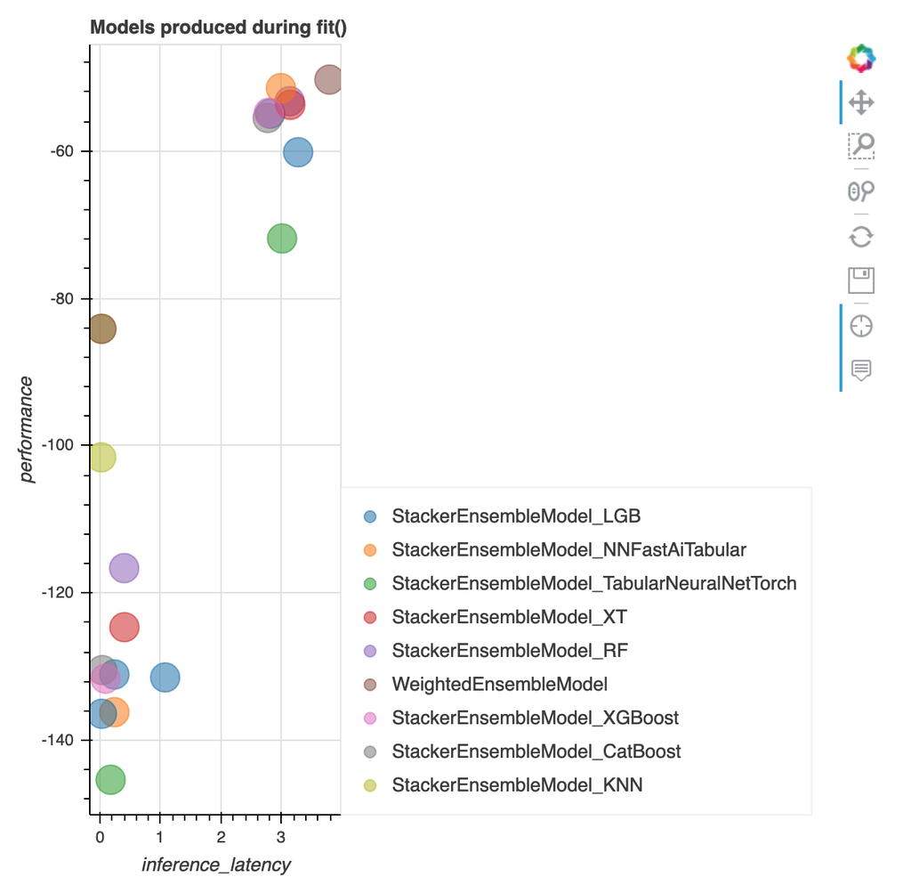

```python
# pd df of leaderboard
display(predictor.leaderboard(silent=True))
```

|  | model | score_val | pred_time_val | fit_time | pred_time_val_marginal | fit_time_marginal | stack_level | can_infer | fit_order |
| --- | --- | --- | --- | --- | --- | --- | --- | --- | --- |
| 0 | WeightedEnsemble_L3 | -50.323383 | 3.790765 | 481.792419 | 0.000937 | 0.355156 | 3 | True | 21 |
| 1 | NeuralNetFastAI_BAG_L2 | -51.485907 | 2.988411 | 470.686510 | 0.250229 | 78.210064 | 2 | True | 18 |
| 2 | RandomForestMSE_BAG_L2 | -53.246498 | 3.133175 | 400.799237 | 0.394993 | 8.322791 | 2 | True | 15 |
| 3 | ExtraTreesMSE_BAG_L2 | -53.753492 | 3.144606 | 394.904408 | 0.406424 | 2.427962 | 2 | True | 17 |
| 4 | XGBoost_BAG_L2 | -54.823227 | 2.789564 | 402.498739 | 0.051383 | 10.022294 | 2 | True | 19 |
| 5 | LightGBM_BAG_L2 | -54.941664 | 2.812122 | 398.179082 | 0.073940 | 5.702636 | 2 | True | 14 |
| 6 | CatBoost_BAG_L2 | -55.531860 | 2.769607 | 426.847835 | 0.031425 | 34.371390 | 2 | True | 16 |
| 7 | LightGBMXT_BAG_L2 | -60.183233 | 3.273202 | 409.839394 | 0.535020 | 17.362948 | 2 | True | 13 |
| 8 | NeuralNetTorch_BAG_L2 | -71.887929 | 3.007832 | 429.684303 | 0.269650 | 37.207857 | 2 | True | 20 |
| 9 | KNeighborsDist_BAG_L1 | -84.146423 | 0.024636 | 0.026423 | 0.024636 | 0.026423 | 1 | True | 2 |
| 10 | WeightedEnsemble_L2 | -84.146423 | 0.025243 | 0.389033 | 0.000607 | 0.362610 | 2 | True | 12 |
| 11 | KNeighborsUnif_BAG_L1 | -101.588176 | 0.020325 | 0.029242 | 0.020325 | 0.029242 | 1 | True | 1 |
| 12 | RandomForestMSE_BAG_L1 | -116.621736 | 0.399784 | 3.318462 | 0.399784 | 3.318462 | 1 | True | 5 |
| 13 | ExtraTreesMSE_BAG_L1 | -124.637158 | 0.403308 | 1.646395 | 0.403308 | 1.646395 | 1 | True | 7 |
| 14 | CatBoost_BAG_L1 | -130.461205 | 0.038730 | 221.421865 | 0.038730 | 221.421865 | 1 | True | 6 |
| 15 | LightGBM_BAG_L1 | -131.054162 | 0.238382 | 7.063493 | 0.238382 | 7.063493 | 1 | True | 4 |
| 16 | LightGBMXT_BAG_L1 | -131.460909 | 1.076571 | 24.637509 | 1.076571 | 24.637509 | 1 | True | 3 |
| 17 | XGBoost_BAG_L1 | -131.624665 | 0.089945 | 9.603428 | 0.089945 | 9.603428 | 1 | True | 9 |
| 18 | NeuralNetFastAI_BAG_L1 | -136.179467 | 0.237922 | 82.469724 | 0.237922 | 82.469724 | 1 | True | 8 |
| 19 | LightGBMLarge_BAG_L1 | -136.395115 | 0.031796 | 1.820606 | 0.031796 | 1.820606 | 1 | True | 11 |
| 20 | NeuralNetTorch_BAG_L1 | -145.350120 | 0.176783 | 40.439298 | 0.176783 | 40.439298 | 1 | True | 10 |

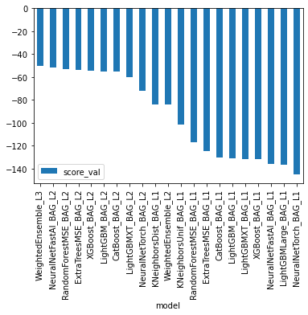

```python
# Output the model's `score_val` in a bar chart to compare performance
predictor.leaderboard(silent=True).plot(kind="bar", x="model", y="score_val");
```

### Create predictions from test dataset

```python
predictions = predictor.predict(test)
predictions.head()
```

```
0    26.956022
1    40.791515
2    46.149269
3    48.812576
4    51.097126
Name: count, dtype: float32
```

#### NOTE: Kaggle will reject the submission if we don't set everything to be > 0.

```python
# Describe the `predictions` series to see if there are any negative values
predictions.describe()
```

```
count    6493.000000
mean       99.783821
std        87.645195
min        -0.473958
25%        21.861607
50%        67.521507
75%       165.696167
max       349.640869
Name: count, dtype: float64
```

```python
# How many negative values do we have?
import numpy as np
predictions[predictions < 0].size
```

```
3
```

```python
# Set negative values to zero
predictions[predictions < 0] = 0
```

```python
# Checking
predictions[predictions < 0].size
```

```
0
```

```python
predictions
```

```
0        26.956022
1        40.791515
2        46.149269
3        48.812576
4        51.097126
           ...
6488    149.371155
6489    149.373993
6490    147.974564
6491    141.664948
6492    142.791122
Name: count, Length: 6493, dtype: float32
```

### Set predictions to submission dataframe, save, and submit

```python
submission["count"] = predictions
submission.to_csv("submission.csv", index=False)
```

```python
!kaggle competitions submit -c bike-sharing-demand -f submission.csv -m "first 'submit'"
```

```
Successfully submitted to Bike Sharing Demand
```

#### View submission via the command line or in the web browser under the competition's page - `My Submissions`

```python
!kaggle competitions submissions -c bike-sharing-demand | tail -n +1 | head -n 6
```

```
fileName                     date                 description                           status    publicScore  privateScore
---------------------------  -------------------  ------------------------------------  --------  -----------  ------------
submission.csv               2022-08-13 22:30:10  first 'submit'                        complete  1.78306      1.78306
submission_new_hpo.csv       2022-08-08 15:56:13  new features with hyperparameters v2  complete  0.72622      0.72622
submission_new_features.csv  2022-08-08 15:55:51  new features v2                       complete  0.73771      0.73771
submission.csv               2022-08-08 15:55:28  first 'submit'                        complete  1.77030      1.77030
```

#### Initial score of `1.78306`

## Step 4: Exploratory Data Analysis and Creating an additional feature

- Any additional feature will do, but a great suggestion would be to separate out the datetime into hour, day, or month parts.

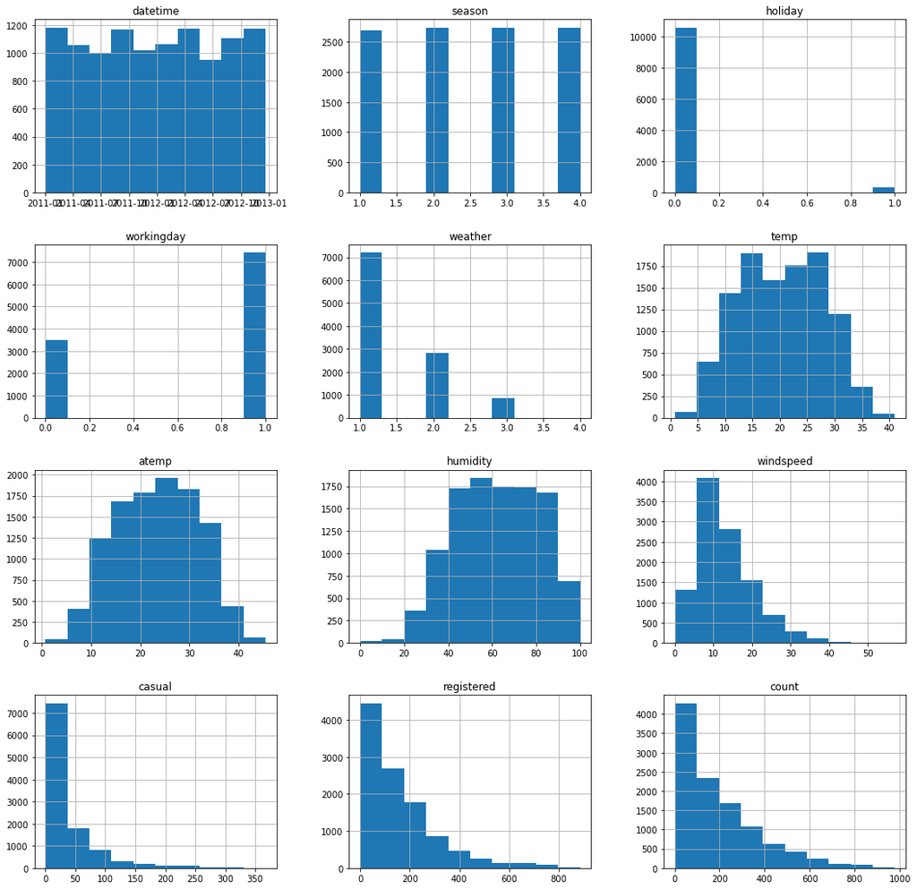

```python
# Create a histogram of all features to show the distribution of each one relative to the data. This is part of the exploritory data analysis
import matplotlib.pyplot as plt

train.hist(figsize=(18,18));
```

- A histogram provides a visual representation of the distribution of a dataset: location, spread and skewness of the data; it also helps to visualize whether the distribution is symmetric or skewed left or right. In addition, if it is unimodal, bimodal or multimodal.
- It can also show any outliers or gaps in the data. In brief, a histogram summarizes the distribution properties of a continuous numerical variable

```python
# create a new feature
train['year'] = train['datetime'].dt.year
train['month'] = train['datetime'].dt.month
train['day'] = train['datetime'].dt.day
train['hour'] = train['datetime'].dt.hour # this is valueable!

test['year'] = test['datetime'].dt.year
test['month'] = test['datetime'].dt.month
test['day'] = test['datetime'].dt.day
test['hour'] = test['datetime'].dt.hour
```

```python
train['hour'][:5]
```

```
0    0
1    1
2    2
3    3
4    4
Name: hour, dtype: int64
```

## Make category types for these so models know they are not just numbers

- AutoGluon originally sees these as ints, but in reality they are int representations of a category.
- Setting the dtype to category will classify these as categories in AutoGluon.

```python
train["season"] = train['season'].astype('category')
train["weather"] = train['weather'].astype('category')
test["season"] = test['season'].astype('category')
test["weather"] = test['weather'].astype('category')
```

```python
train["holiday"] = train["holiday"].astype("category")
train["workingday"] = train["workingday"].astype("category")
test["holiday"] = test["holiday"].astype("category")
test["workingday"] = test["workingday"].astype("category")
```

```python
# View are new feature
train.head()
```

|  | datetime | season | holiday | workingday | weather | temp | atemp | humidity | windspeed | casual | registered | count | year | month | day | hour |
| --- | --- | --- | --- | --- | --- | --- | --- | --- | --- | --- | --- | --- | --- | --- | --- | --- |
| 0 | 2011-01-01 00:00:00 | 1 | 0 | 0 | 1 | 9.84 | 14.395 | 81 | 0.0 | 3 | 13 | 16 | 2011 | 1 | 1 | 0 |
| 1 | 2011-01-01 01:00:00 | 1 | 0 | 0 | 1 | 9.02 | 13.635 | 80 | 0.0 | 8 | 32 | 40 | 2011 | 1 | 1 | 1 |
| 2 | 2011-01-01 02:00:00 | 1 | 0 | 0 | 1 | 9.02 | 13.635 | 80 | 0.0 | 5 | 27 | 32 | 2011 | 1 | 1 | 2 |
| 3 | 2011-01-01 03:00:00 | 1 | 0 | 0 | 1 | 9.84 | 14.395 | 75 | 0.0 | 3 | 10 | 13 | 2011 | 1 | 1 | 3 |
| 4 | 2011-01-01 04:00:00 | 1 | 0 | 0 | 1 | 9.84 | 14.395 | 75 | 0.0 | 0 | 1 | 1 | 2011 | 1 | 1 | 4 |

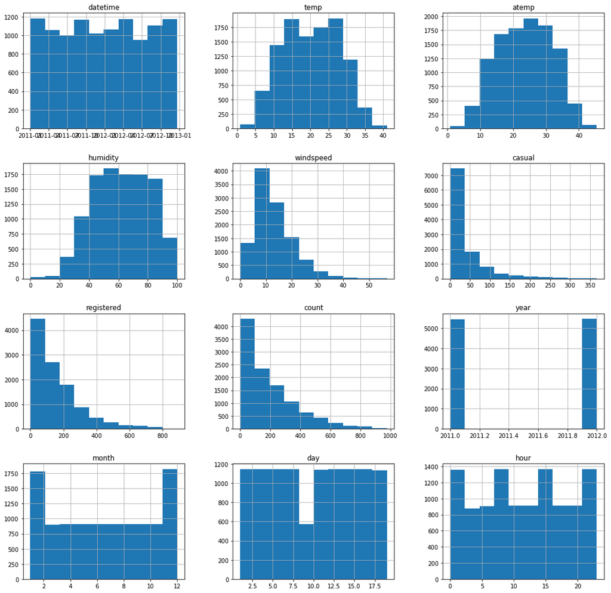

```python
# View histogram of all features again now with the hour feature
train.hist(figsize=(18,18));
```

## Step 5: Rerun the model with the same settings as before, just with more features

```python
predictor_new_features = TabularPredictor(
    label='count',
    learner_kwargs={'ignored_columns': ["casual", "registered"]},
    problem_type='regression',
    eval_metric='root_mean_squared_error'
).fit(
    train_data=train,
    time_limit=600,
    presets='best_quality'
)
```

[output not shown]

[output not shown]

```
	-34.346	 = Validation score   (root_mean_squared_error)
	36.86s	 = Training   runtime
	1.62s	 = Validation runtime
Fitting model: LightGBM_BAG_L1 ... Training model for up to 358.34s of the 558.39s of remaining time.
	Fitting 8 child models (S1F1 - S1F8) | Fitting with SequentialLocalFoldFittingStrategy
```

[output not shown]

[output not shown]

```
[1000]	valid_set's rmse: 32.8192
[1000]	valid_set's rmse: 31.2898
```

[output not shown]

```python
predictor_new_features.fit_summary()
```

```
*** Summary of fit() ***
Estimated performance of each model:
                     model   score_val  pred_time_val    fit_time  pred_time_val_marginal  fit_time_marginal  stack_level  can_infer  fit_order
0      WeightedEnsemble_L3  -29.227675       3.645128  552.639526                0.000474           0.250295            3       True         18
1   NeuralNetFastAI_BAG_L2  -29.535017       3.432222  465.818667                0.240246          75.235831            2       True         15
2          CatBoost_BAG_L2  -30.293489       3.243312  462.578566                0.051336          71.995730            2       True         13
3          LightGBM_BAG_L2  -30.318279       3.279460  395.743097                0.087485           5.160262            2       True         11
4           XGBoost_BAG_L2  -30.543500       3.265588  399.997408                0.073612           9.414572            2       True         16
5     ExtraTreesMSE_BAG_L2  -31.297050       3.643083  393.120669                0.451107           2.537833            2       True         14
6        LightGBMXT_BAG_L2  -31.355036       3.333804  397.047121                0.141828           6.464286            2       True         10
7   RandomForestMSE_BAG_L2  -31.476662       3.634572  398.831107                0.442596           8.248271            2       True         12
8      WeightedEnsemble_L2  -32.022422       2.563937  379.186059                0.000496           0.278219            2       True          9
9          CatBoost_BAG_L1  -33.381414       0.081186  323.565901                0.081186         323.565901            1       True          6
10   NeuralNetTorch_BAG_L2  -33.792963       3.439039  407.185407                0.247063          16.602571            2       True         17
11         LightGBM_BAG_L1  -33.917339       0.449650   14.589901                0.449650          14.589901            1       True          4
12       LightGBMXT_BAG_L1  -34.345997       1.618440   36.859094                1.618440          36.859094            1       True          3
13    ExtraTreesMSE_BAG_L1  -38.202438       0.383204    1.609773                0.383204           1.609773            1       True          7
14  RandomForestMSE_BAG_L1  -38.357786       0.392124    3.874818                0.392124           3.874818            1       True          5
15   KNeighborsDist_BAG_L1  -84.146423       0.022040    0.018126                0.022040           0.018126            1       True          2
16   KNeighborsUnif_BAG_L1 -101.588176       0.017940    0.020384                0.017940           0.020384            1       True          1
17  NeuralNetFastAI_BAG_L1 -110.317794       0.227391   10.044838                0.227391          10.044838            1       True          8
Number of models trained: 18
Types of models trained:
{'StackerEnsembleModel_LGB', 'StackerEnsembleModel_NNFastAiTabular', 'StackerEnsembleModel_TabularNeuralNetTorch', 'StackerEnsembleModel_XT', 'StackerEnsembleModel_RF', 'WeightedEnsembleModel', 'StackerEnsembleModel_XGBoost', 'StackerEnsembleModel_CatBoost', 'StackerEnsembleModel_KNN'}
Bagging used: True  (with 8 folds)
Multi-layer stack-ensembling used: True  (with 3 levels)
Feature Metadata (Processed):
(raw dtype, special dtypes):
('category', [])             : 2 | ['season', 'weather']
('float', [])                : 3 | ['temp', 'atemp', 'windspeed']
('int', [])                  : 4 | ['humidity', 'month', 'day', 'hour']
('int', ['bool'])            : 3 | ['holiday', 'workingday', 'year']
('int', ['datetime_as_int']) : 5 | ['datetime', 'datetime.year', 'datetime.month', 'datetime.day', 'datetime.dayofweek']
Plot summary of models saved to file: AutogluonModels/ag-20220813_223247/SummaryOfModels.html
*** End of fit() summary ***
```

[output not shown]

[output cut: 175 more lines]

```
 3          11
 4          16
 5          14
 6          10
 7          12
 8           9
 9           6
 10         17
 11          4
 12          3
 13          7
 14          5
 15          2
 16          1
 17          8  }
```

```python
# predictor_new_features.fit_summary(show_plot=True)
```

[figure not shown]

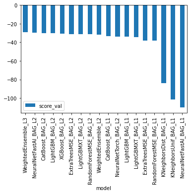

```python
predictor_new_features.leaderboard(silent=True).plot(kind="bar", x="model", y="score_val");
```

```python
# Remember to set all negative values to zero
predictions_new = predictor_new_features.predict(test)
predictions_new.head()
```

```
0    14.320723
1     9.185234
2     8.720471
3     8.815825
4     8.774405
Name: count, dtype: float32
```

```python
predictions_new[predictions_new < 0] = 0
```

```python
# Same submitting predictions
submission_new_features = pd.read_csv('sampleSubmission.csv', parse_dates=["datetime"])
submission_new_features["count"] = predictions_new
submission_new_features.to_csv("submission_new_features.csv", index=False)
```

```python
!kaggle competitions submit -c bike-sharing-demand -f submission_new_features.csv -m "new features v2 redo"
```

```
Successfully submitted to Bike Sharing Demand
```

```python
!kaggle competitions submissions -c bike-sharing-demand | tail -n +1 | head -n 6
```

```
fileName                     date                 description                           status    publicScore  privateScore
---------------------------  -------------------  ------------------------------------  --------  -----------  ------------
submission_new_features.csv  2022-08-13 22:56:24  new features v2 redo                  complete  0.74715      0.74715
submission.csv               2022-08-13 22:30:10  first 'submit'                        complete  1.78306      1.78306
submission_new_hpo.csv       2022-08-08 15:56:13  new features with hyperparameters v2  complete  0.72622      0.72622
submission_new_features.csv  2022-08-08 15:55:51  new features v2                       complete  0.73771      0.73771
```

#### New Score of `0.74715`

## Step 6: Hyper parameter optimization

- There are many options for hyper parameter optimization.
- Options are to change the AutoGluon higher level parameters or the individual model hyperparameters.
- The hyperparameters of the models themselves that are in AutoGluon. Those need the `hyperparameter` and `hyperparameter_tune_kwargs` arguments.

```python
import autogluon.core as ag

nn_options = {  # specifies non-default hyperparameter values for neural network models
    'num_epochs': 15,  # number of training epochs (controls training time of NN models)
    'learning_rate': ag.space.Real(1e-4, 1e-2, default=5e-4, log=True),  # learning rate used in training (real-valued hyperparameter searched on log-scale)
    'activation': ag.space.Categorical('relu', 'softrelu', 'tanh'),  # activation function used in NN (categorical hyperparameter, default = first entry)
    'layers': ag.space.Categorical([100], [1000], [200, 100], [300, 200, 100]),  # each choice for categorical hyperparameter 'layers' corresponds to list of sizes for each NN layer to use
    'dropout_prob': ag.space.Real(0.0, 0.5, default=0.1),  # dropout probability (real-valued hyperparameter)
}

gbm_options = {  # specifies non-default hyperparameter values for lightGBM gradient boosted trees
    'num_boost_round': 100,  # number of boosting rounds (controls training time of GBM models)
    'num_leaves': ag.space.Int(lower=26, upper=66, default=36),  # number of leaves in trees (integer hyperparameter)
}

hyperparameters = {  # hyperparameters of each model type
                   'GBM': gbm_options,
                   'NN': nn_options,
                  }  # When these keys are missing from hyperparameters dict, no models of that type are trained

hyperparameter_tune_kwargs = {  # HPO is not performed unless hyperparameter_tune_kwargs is specified
    'num_trials': 4, # try at most 4 different hyperparameter configurations for each type of model
    'scheduler' : 'local',
    'searcher': 'auto', # to tune hyperparameters using random search routine with a local scheduler
}

predictor_new_hpo = TabularPredictor(
    label='count',
    learner_kwargs={'ignored_columns': ["casual", "registered"]},
    problem_type='regression',
    eval_metric='root_mean_squared_error'
).fit(
    train_data=train,
    time_limit=600,
    presets='best_quality',
    num_bag_folds=6,
    num_bag_sets=1,
    num_stack_levels=1,
    hyperparameters=hyperparameters,
    hyperparameter_tune_kwargs=hyperparameter_tune_kwargs
)

# https://docs.aws.amazon.com/sagemaker/latest/dg/autogluon-tabular-hyperparameters.html
```

[output not shown]

```
Fitted model: LightGBM_BAG_L1/T1 ...
	-40.6459	 = Validation score   (root_mean_squared_error)
	0.41s	 = Training   runtime
	0.01s	 = Validation runtime
Fitted model: LightGBM_BAG_L1/T2 ...
	-38.7623	 = Validation score   (root_mean_squared_error)
	0.23s	 = Training   runtime
	0.01s	 = Validation runtime
Fitted model: LightGBM_BAG_L1/T3 ...
	-38.9135	 = Validation score   (root_mean_squared_error)
	0.3s	 = Training   runtime
	0.01s	 = Validation runtime
Fitted model: LightGBM_BAG_L1/T4 ...
	-123.1499	 = Validation score   (root_mean_squared_error)
	0.2s	 = Training   runtime
	0.01s	 = Validation runtime
Hyperparameter tuning model: NeuralNetMXNet_BAG_L1 ... Tuning model for up to 29.98s of the 598.37s of remaining time.
```

```
	WARNING: TabularNeuralNetMxnetModel (alias "NN" & "NN_MXNET") has been deprecated in v0.4.0.
		Starting in v0.5.0, calling TabularNeuralNetMxnetModel will raise an exception.
		Consider instead using TabularNeuralNetTorchModel via "NN_TORCH".
	Stopping HPO to satisfy time limit...
Fitted model: NeuralNetMXNet_BAG_L1/T1 ...
	-112.6002	 = Validation score   (root_mean_squared_error)
	18.83s	 = Training   runtime
	0.15s	 = Validation runtime
Fitting model: LightGBM_BAG_L1/T1 ... Training model for up to 379.06s of the 579.1s of remaining time.
	Fitting 5 child models (S1F2 - S1F6) | Fitting with SequentialLocalFoldFittingStrategy
```

```
	-40.2368	 = Validation score   (root_mean_squared_error)
	1.42s	 = Training   runtime
	0.04s	 = Validation runtime
Fitting model: LightGBM_BAG_L1/T2 ... Training model for up to 377.98s of the 578.03s of remaining time.
	Fitting 5 child models (S1F2 - S1F6) | Fitting with SequentialLocalFoldFittingStrategy
	-38.9687	 = Validation score   (root_mean_squared_error)
	1.19s	 = Training   runtime
	0.04s	 = Validation runtime
Fitting model: LightGBM_BAG_L1/T3 ... Training model for up to 376.95s of the 576.99s of remaining time.
	Fitting 5 child models (S1F2 - S1F6) | Fitting with SequentialLocalFoldFittingStrategy
	-38.6143	 = Validation score   (root_mean_squared_error)
	1.5s	 = Training   runtime
	0.04s	 = Validation runtime
Fitting model: LightGBM_BAG_L1/T4 ... Training model for up to 375.67s of the 575.71s of remaining time.
	Fitting 5 child models (S1F2 - S1F6) | Fitting with SequentialLocalFoldFittingStrategy
	-121.9906	 = Validation score   (root_mean_squared_error)
	1.26s	 = Training   runtime
	0.05s	 = Validation runtime
Fitting model: NeuralNetMXNet_BAG_L1/T1 ... Training model for up to 374.53s of the 574.57s of remaining time.
	Fitting 5 child models (S1F2 - S1F6) | Fitting with SequentialLocalFoldFittingStrategy
	-107.19	 = Validation score   (root_mean_squared_error)
	53.05s	 = Training   runtime
	0.9s	 = Validation runtime
Fitting model: WeightedEnsemble_L2 ... Training model for up to 360.0s of the 539.56s of remaining time.
	-38.1227	 = Validation score   (root_mean_squared_error)
	0.15s	 = Training   runtime
	0.0s	 = Validation runtime
	WARNING: "NN" model has been deprecated in v0.4.0 and renamed to "NN_MXNET". Starting in v0.5.0, specifying "NN" or "NN_MXNET" will raise an exception. Consider instead specifying "NN_TORCH".
Fitting 2 L2 models ...
Hyperparameter tuning model: LightGBM_BAG_L2 ... Tuning model for up to 40.45s of the 539.38s of remaining time.
```

```
Fitted model: LightGBM_BAG_L2/T1 ...
	-40.4347	 = Validation score   (root_mean_squared_error)
	0.19s	 = Training   runtime
	0.01s	 = Validation runtime
Fitted model: LightGBM_BAG_L2/T2 ...
	-39.6868	 = Validation score   (root_mean_squared_error)
	0.2s	 = Training   runtime
	0.01s	 = Validation runtime
Fitted model: LightGBM_BAG_L2/T3 ...
	-40.2663	 = Validation score   (root_mean_squared_error)
	0.25s	 = Training   runtime
	0.01s	 = Validation runtime
Fitted model: LightGBM_BAG_L2/T4 ...
	-103.5134	 = Validation score   (root_mean_squared_error)
	0.21s	 = Training   runtime
	0.0s	 = Validation runtime
Hyperparameter tuning model: NeuralNetMXNet_BAG_L2 ... Tuning model for up to 40.45s of the 538.34s of remaining time.
```

```
	Stopping HPO to satisfy time limit...
```

[output not shown]

```python
predictor_new_hpo.fit_summary()
```

```
*** Summary of fit() ***
Estimated performance of each model:
                       model   score_val  pred_time_val    fit_time  pred_time_val_marginal  fit_time_marginal  stack_level  can_infer  fit_order
0        WeightedEnsemble_L3  -36.095896       2.181812  113.704739                0.000479           0.221173            3       True         14
1         LightGBM_BAG_L2/T2  -36.389968       1.120154   59.802809                0.040451           1.378620            2       True          8
2         LightGBM_BAG_L2/T3  -36.756334       1.129738   60.188166                0.050035           1.763977            2       True          9
3         LightGBM_BAG_L2/T1  -36.835276       1.129765   59.839061                0.050062           1.414873            2       True          7
4   NeuralNetMXNet_BAG_L2/T3  -37.548193       2.090847  110.340969                1.011145          51.916780            2       True         13
5        WeightedEnsemble_L2  -38.122685       0.083962    2.847571                0.000471           0.152418            2       True          6
6         LightGBM_BAG_L1/T3  -38.614300       0.044151    1.501349                0.044151           1.501349            1       True          3
7         LightGBM_BAG_L1/T2  -38.968710       0.039341    1.193804                0.039341           1.193804            1       True          2
8         LightGBM_BAG_L1/T1  -40.236799       0.040464    1.420986                0.040464           1.420986            1       True          1
9   NeuralNetMXNet_BAG_L2/T2  -45.470734       1.915246  104.376610                0.835544          45.952421            2       True         12
10  NeuralNetMXNet_BAG_L2/T1  -49.027623       2.021699  102.347246                0.941996          43.923057            2       True         11
11        LightGBM_BAG_L2/T4 -102.937419       1.119711   59.778095                0.040008           1.353907            2       True         10
12  NeuralNetMXNet_BAG_L1/T1 -107.190000       0.903885   53.052497                0.903885          53.052497            1       True          5
13        LightGBM_BAG_L1/T4 -121.990638       0.051862    1.255553                0.051862           1.255553            1       True          4
Number of models trained: 14
Types of models trained:
{'StackerEnsembleModel_TabularNeuralNetMxnet', 'StackerEnsembleModel_LGB', 'WeightedEnsembleModel'}
Bagging used: True  (with 6 folds)
Multi-layer stack-ensembling used: True  (with 3 levels)
Feature Metadata (Processed):
(raw dtype, special dtypes):
('category', [])             : 2 | ['season', 'weather']
('float', [])                : 3 | ['temp', 'atemp', 'windspeed']
('int', [])                  : 4 | ['humidity', 'month', 'day', 'hour']
('int', ['bool'])            : 3 | ['holiday', 'workingday', 'year']
('int', ['datetime_as_int']) : 5 | ['datetime', 'datetime.year', 'datetime.month', 'datetime.day', 'datetime.dayofweek']
Plot summary of models saved to file: AutogluonModels/ag-20220814_001904/SummaryOfModels.html
*** End of fit() summary ***
```

[output not shown]

[output cut: 121 more lines]

```
     fit_order
 0          14
 1           8
 2           9
 3           7
 4          13
 5           6
 6           3
 7           2
 8           1
 9          12
 10         11
 11         10
 12          5
 13          4  }
```

```python
# Remember to set all negative values to zero
predictions_hpo = predictor_new_hpo.predict(test)
predictions_hpo.head()
```

```
0    9.430254
1    6.552686
2    6.301128
3    6.333421
4    6.382062
Name: count, dtype: float32
```

```python
predictions_hpo[predictions_hpo < 0] = 0
```

```python
# Same submitting predictions
submission_new_hpo = pd.read_csv('sampleSubmission.csv', parse_dates=["datetime"])
submission_new_hpo["count"] = predictions_hpo
submission_new_hpo.to_csv("submission_new_hpo.csv", index=False)
```

```python
!kaggle competitions submit -c bike-sharing-demand -f submission_new_hpo.csv -m "new features with hyperparameters v2 - Redo"
```

```
Successfully submitted to Bike Sharing Demand
```

```python
!kaggle competitions submissions -c bike-sharing-demand | tail -n +1 | head -n 6
```

```
fileName                     date                 description                                  status    publicScore  privateScore
---------------------------  -------------------  -------------------------------------------  --------  -----------  ------------
submission_new_hpo.csv       2022-08-14 00:27:32  new features with hyperparameters v2 - Redo  complete  0.48410      0.48410
submission_new_features.csv  2022-08-13 22:56:24  new features v2 redo                         complete  0.74715      0.74715
submission.csv               2022-08-13 22:30:10  first 'submit'                               complete  1.78306      1.78306
submission_new_hpo.csv       2022-08-08 15:56:13  new features with hyperparameters v2         complete  0.72622      0.72622
```

#### New Score of `0.48410`

## Step 7: Write a Report

### Refer to the markdown file for the full report

### Creating plots and table for report

```python
predictor_new_hpo2 = TabularPredictor(
    label='count',
    learner_kwargs={'ignored_columns': ["casual", "registered"]},
    problem_type='regression',
    eval_metric='root_mean_squared_error'
).fit(
    train_data=train,
    time_limit=900, # increase time limit
    presets='best_quality',
    num_bag_folds=10, # increase
    num_bag_sets=20, # increase
    num_stack_levels=3 # increase
)

predictions_hpo2 = predictor_new_hpo2.predict(test)
predictions_hpo2[predictions_hpo2 < 0] = 0

submission_new_hpo2 = pd.read_csv('sampleSubmission.csv', parse_dates=["datetime"])
submission_new_hpo2["count"] = predictions_hpo2
submission_new_hpo2.to_csv("submission_new_hpo2.csv", index=False)
```

[output not shown]

[output not shown]

```
	-34.0338	 = Validation score   (root_mean_squared_error)
	54.0s	 = Training   runtime
	2.82s	 = Validation runtime
Fitting model: LightGBM_BAG_L1 ... Training model for up to 238.23s of the 838.21s of remaining time.
	Fitting 10 child models (S1F1 - S1F10) | Fitting with SequentialLocalFoldFittingStrategy
```

[output not shown]

[output not shown]

[output cut: 15 more lines]

```
	Ran out of time, early stopping on iteration 115. Best iteration is:
	[115]	valid_set's rmse: 40.4236
	Ran out of time, early stopping on iteration 115. Best iteration is:
	[115]	valid_set's rmse: 37.9466
	-41.2377	 = Validation score   (root_mean_squared_error)
	3.14s	 = Training   runtime
	0.05s	 = Validation runtime
Completed 1/20 k-fold bagging repeats ...
Fitting model: WeightedEnsemble_L2 ... Training model for up to 360.0s of the 599.96s of remaining time.
	-31.834	 = Validation score   (root_mean_squared_error)
	0.26s	 = Training   runtime
	0.0s	 = Validation runtime
Fitting 9 L2 models ...
Fitting model: LightGBMXT_BAG_L2 ... Training model for up to 266.46s of the 599.68s of remaining time.
	Fitting 10 child models (S1F1 - S1F10) | Fitting with SequentialLocalFoldFittingStrategy
```